# Statistical Graphics and Communication

Stefany Coxe

October 24, 2019

# Checking model assumptions

## Model fit

Always check a model’s fit

- Check for outliers (model-based and non-model-based)
- Check whether model assumptions (e.g., homoscedasticity) are satisfied
- Evaluate overall measures of fit such as $R^2_{mult}$
- Evaluate case-specific measures of fit

## Outlier statistics

There are three types of outlier statistics to examine

- Leverage: outliers in predictor space
- Discrepancy: differences between observed and predicted values
- Influence: actually changing predicted values or regression coefficients

Cases with high leverage and high discrepancy have the *potential* to change results

- Cases with low leverage and/or low discrepancy don’t really

## Leverage: hat matrix

Leverage measure comes from the *hat matrix*

- Hat matrix: $X_A (X'_A X_A)^{-1} X'_A$
- $\hat Y = X_A (X'_A X_A)^{-1} X'_A Y$: “puts the hats on the Ys”
- How far is a case’s predictor value(s) from the center of the points?
- $h_{ii}$ = leverage value for case i

## Predicted values

Predicted value: *outcome* values the model predicts for each case

Also called “model-based” or “model-implied”

$R^2_{mult}$ is the correlation between observed outcome values and predicted outcome values

## Discrepancy: Residuals

Raw residuals are the difference between the observed outcome value and the predicted outcome value

$e_i = Y_{i} - \hat Y_i$

where $Y_{i}$ is case i’s observed outcome

and $\hat Y_i$ is case i’s predicted outcome

Hard to interpret because the metric depends on the metric of the outcome variable

- Standardizing residuals helps interpretation

## Discrepancy: Residuals (standardized)

There are two main ways to standardize residuals

**Internally standardized** (or studentized) residuals are the residual divided by the standard deviation for the residual

- internally studentized residual $= e_i / SD_{e_i}$

where $SD_{e_i} = \sqrt{ MS_{error}(1 - h_{ii})}$

## Discrepancy: Residuals (standardized)

**Externally standardized** (or deleted studentized) residuals are the residual (with predicted value from a model with the point deleted) divided by the standard deviation for the residual (from a model with the point deleted)

- externally studentized residual $= d_i / SD_d$

where the subscript $(i)$ refers to the value from a model with case i deleted

and $d_i = Y_i - \hat Y_{i(i)}$

and $SD_d = \sqrt{ MS_{error(i)}(1 - h_{ii})}$

- Use the `rstudent()` function to calculate

## Influence: Cook’s D

How much the case is changing the predicted value

Several possible cut-off values

- 3*mean(Cook’s d)
- 4 / n

## Influence: DFFITS

How much the case is changing the predicted value

Cut-offs: > 1 for small to medium samples, $2\sqrt{(k + 1)/n}$ for large samples

- Use the `dffits()` function to calculate

## Influence: DFBETAS

How much the case is changing the regression coefficients

One value per case, per regression coefficient (including intercept)

Cut-offs: > $\pm$ 1 for small to medium samples, $\pm 2/\sqrt{n}$ for large samples

- Use the `dfbetas()` function to calculate, but best to calculate separately for each predictor to get the datasets to merge smoothly

# Some plotting stuff

## **broom()** package

`tidy()`: put the regression coefficients, standard errors, p-values, etc. into a data frame

`glance()`: put the global model fit statistics - $R^2$, AIC into a data frame

`augment()`: put the predictor, outcome, predicted values, residuals, etc. into a data frame

Only required argument is the *model object*

## Some plots to consider

QQ plot: assess normality

- Residuals (raw) as proxy for conditional normality

Index plot: easily spot extreme values

- Leverage, (standardized) residuals, Cook’s d, DFFITS, DFBETAS

Scatterplot: look for relationships (with smooth line)

- X = predictor or predicted value, Y = residual (should be no relationship with constant variance)

## Residuals versus predicted value

```r
data(FirstYearGPA)
#glimpse(FirstYearGPA)
model2 <- lm(GPA ~ SATV, data = FirstYearGPA)

model2_res <- augment(model2)

res_vs_fit <- ggplot(data = model2_res,
                     aes(x = .fitted, y = .resid)) +
  labs(x = "Predicted GPA", y = "Raw residual") +
  geom_point() +
  geom_smooth(method = loess, se = TRUE)
```

## Residuals versus predicted value

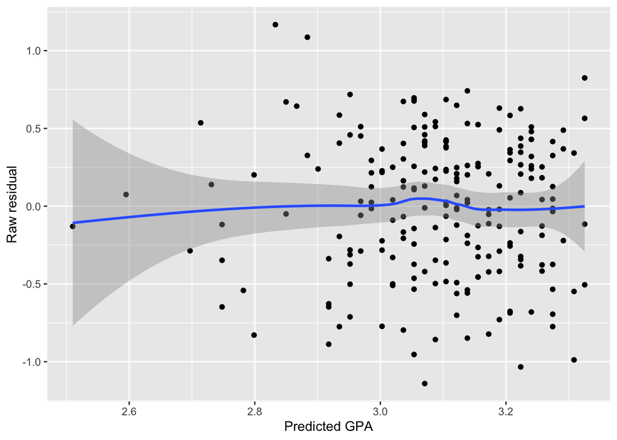

```r
res_vs_fit
```

## Fancy plot of residuals

Plot of vertical residual line

```r
fancy_res <- ggplot(data = model2_res,
                    aes(x = SATV, y = GPA)) +
  geom_point() +
  geom_smooth(method = "lm", se = FALSE,
              color = "lightgrey") +
  geom_segment(aes(xend = SATV, yend = .fitted),
               alpha = .2) +
  geom_point(aes(y = .fitted), shape = 1)
```

## Fancy plot of residuals

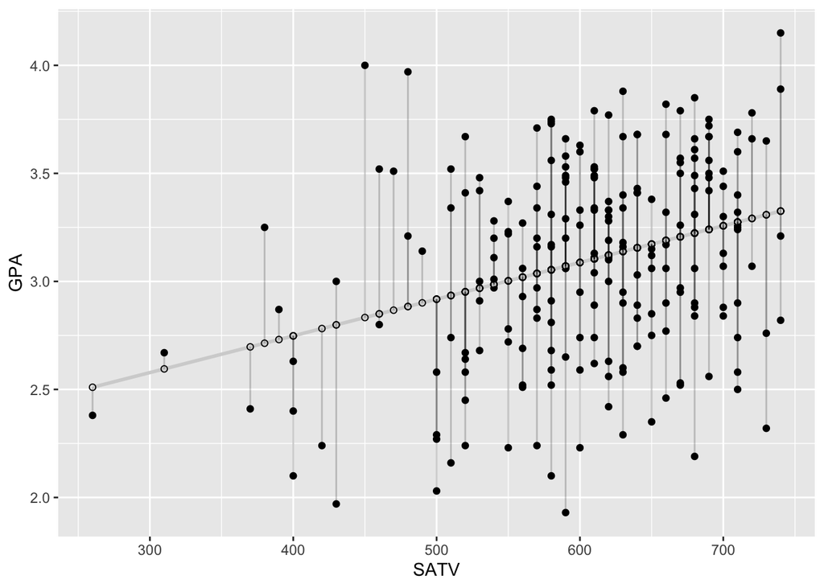

```r
fancy_res
```